# Homework before A2 Class

Ben

Saturday, May 09, 2015

## 複習

在A2的課程開始之前，請大家先複習一下A1的課程，尤其是與R相關的部分：

- http://dspim.github.io/A1-EDA-R/EDA-R.html
- http://dspim.github.io/A1-EDA-R/intro-rmd/
- https://dspim.github.io/A1-EDA-R/answer-advanced-EDA.html

## 以下兩個小問題，請大家練習一下：

### 1.

小明想在永和找到新房子，希望以後上下班都靠Ubike通勤，希望早上可以輕鬆租到車，下班後也可以輕鬆還車，請幫他找出永和區早上七點腳踏車最多的場站，並且畫出一天24小時的平均空車率。

- 提示：
  - 會使用到的package: dplyr、ggplot2、ggmap
  - select可用來挑選需要用到的欄位
  - filter可選出符合條件的資料
  - group_by針對同一欄的元素分類
  - summarise搭配group_by將同一類的值一起處理
  - 利用order排序找出車最多的地點，`help(order)`會幫你
  - 請用geom_bar畫bar plot

**結果如下：**

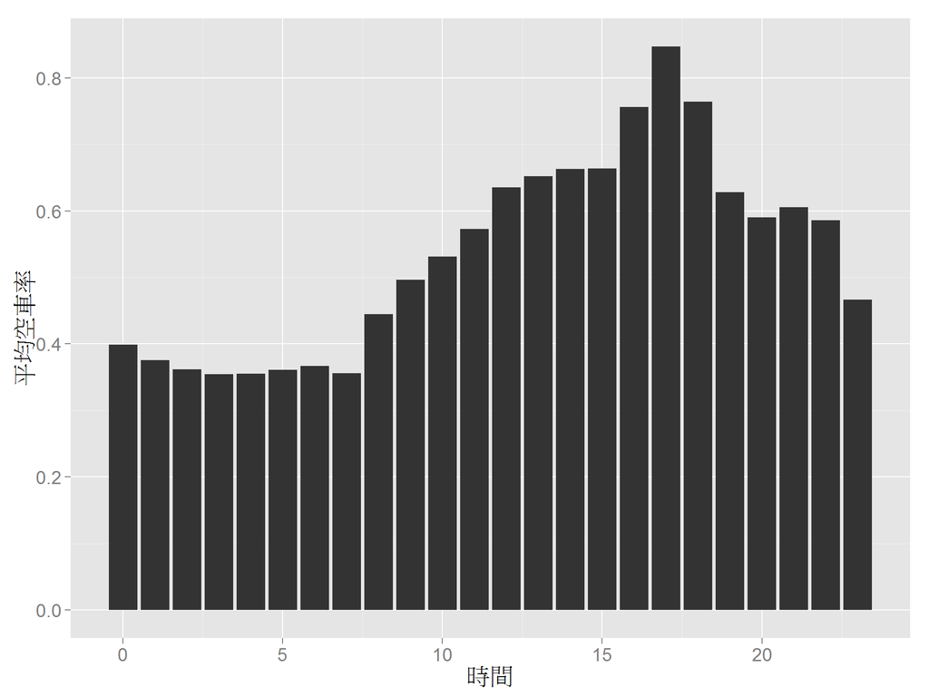

```r
library(dplyr)
library(ggplot2)
library(magrittr)


# 讀檔，path請自行代入檔案路徑，如：'D:/Downloads/ubikeweatherbig5.csv'
ubike <- read.table(path, sep = ",", header = TRUE,
         colClasses = c("factor", "integer","integer", "factor", "factor",
                        "numeric", "numeric", "integer", "numeric", "integer",
                        "integer","numeric", "numeric", "integer", "integer",
                        "numeric", "numeric","numeric", "numeric", "numeric", "numeric"))

# 挑選永和區與早上7點，算每個場站的平均車數
ubike1<- select(ubike,hour,sarea,sna,avg.sbi) %>%
  filter(sarea=='永和區' & hour==7) %>%
  group_by(sna) %>%
  summarise(avg=mean(avg.sbi))

# 將平均車數排序，decreasing=TRUE，表示數字由大排到小
order_avg<-order(ubike1[["avg"]],decreasing = TRUE)

# 排序後，order_avg的第一個值即為ubike1[["avg"]]的最大值
target=ubike1[["sna"]][order_avg[1]]

# 新增一欄作為空車率rate，並挑出平均車數最大的場站，計算每小時的平均空車率avg.rate
ubike2<- select(ubike,hour,sna,tot,avg.bemp) %>%
  mutate(rate=avg.bemp/tot) %>%
  filter(sna==target) %>%
  group_by(hour) %>%
  summarise(avg.rate=mean(rate))

# 使用geom_bar畫bar plot，設定stat='identity'，才能讓bar的高度依照avg.rate畫出
# text=element_text(size=20)控制字體大小
ggplot(ubike2)+
  geom_bar(aes(x=hour,y=avg.rate),stat='identity')+
  labs(x="時間", y="平均空車率")+
  theme(text=element_text(size=18))
```

### 2.

小明喜歡玩遙控飛機，在永和希望找一個風比較小的地點來玩，請幫他在地圖上圈出每個腳踏車站的位置，並且以圓圈大小表示2014-12-31當天下午3點的風速。

- 提示：
  - 需要的package：ggmap
  - get_map可以從google map抓下地圖
  - 在aes()中可放入size=max.anemo，讓以圓圈大小代表風速

**結果如下：**

[figure not shown]

```r
library(ggmap)
# 選擇永和區2014-12-31下午3點
ubike3<- filter(ubike,sarea=='永和區', date=="2014-12-31",hour==15)

# 讀取永和區的地圖，以永和區的第一筆資料的經緯度為中心
m<-get_map(location=c(lon=ubike3$lng[1], lat=ubike3$lat[1]),             maptype = "roadmap", zoom = 14)

# ggmap(m)畫出地圖，並以此為底圖，在地圖上以geom_point畫出圓圈
# aes(x=lng,y=lat,size=max.anemo)，X和Y為經緯度，size則是以max.anemo為依據
# geom_text將站名顯示於地圖上，vjust與hjust分別控制垂直與水平方向的微調
# facebold: 字型樣式，1代表標準，2代表粗體，3代表斜體，4代表斜粗體
# legend.position="none"將原本會出現的legend隱藏
ggmap(m)+
  geom_point(data=ubike3,aes(x=lng,y=lat,size=max.anemo),color='blue',alpha=0.75)+
  scale_size(range = c(5,20))+
  geom_text(data=ubike3,aes(x=lng,y=lat,label=sna),color='red',vjust=-1,hjust=-0.17,fontface=2)+
  theme(text=element_text(size=20),legend.position="none")
```